# Contents

1. Manim in Jupyter Notebook
1. The Bare Minimum
2. Controlling the Scene
1. Using parameters
3. Some More Stuffs
1. Initializing Mobjects Outside the Class
2. Defining Global Mobjects
3. Pre-Execute Slow Code
4. Installing Plugins

# Manim in Jupyter Notebook

[Reference](https://flyingframes.readthedocs.io/en/latest/ch1.html)

## The Bare Minimum

Start by importing `manim`:

```python
from manim import *
```

```
Manim Community v0.17.2
```

You can use `config.media_embed = True` to embed the animation in the notebook. This will result in a larger notebook file, but it will be self-contained.

Now, you can use the `%%manim` magic command to run a scene:

```python
%%manim Shapes

class Shapes(Scene):
    def construct(self):
        circle = Circle()
        square = Square()
        triangle=Polygon(np.array([0,0,0]),np.array([1,1,0]),np.array([1,-1,0]))

        self.play(Create(circle))
        self.play(FadeOut(circle))
        self.play(GrowFromCenter(square))
        self.play(Transform(square,triangle))
```

```
[01/25/23 12:46:35] INFO     Animation 0 : Partial movie file written in                   scene_file_writer.py:527
                             '/media/hari31416/Hari_SSD/Users/harik/Desktop/manim/Notes/me
                             dia/videos/Notes/1080p60/partial_movie_files/Shapes/290269911
                             4_1618171375_223132457.mp4'
```

```
[01/25/23 12:46:36] INFO     Animation 1 : Partial movie file written in                   scene_file_writer.py:527
                             '/media/hari31416/Hari_SSD/Users/harik/Desktop/manim/Notes/me
                             dia/videos/Notes/1080p60/partial_movie_files/Shapes/393193378
                             9_1021491491_3247135320.mp4'
```

```
[01/25/23 12:46:38] INFO     Animation 2 : Partial movie file written in                   scene_file_writer.py:527
                             '/media/hari31416/Hari_SSD/Users/harik/Desktop/manim/Notes/me
                             dia/videos/Notes/1080p60/partial_movie_files/Shapes/393193378
                             9_134669407_223132457.mp4'
```

```
[01/25/23 12:46:40] INFO     Animation 3 : Partial movie file written in                   scene_file_writer.py:527
                             '/media/hari31416/Hari_SSD/Users/harik/Desktop/manim/Notes/me
                             dia/videos/Notes/1080p60/partial_movie_files/Shapes/393193378
                             9_510270977_247722528.mp4'
```

```
                    INFO     Combining to Movie file.                                      scene_file_writer.py:617
```

```
                    INFO                                                                   scene_file_writer.py:736
                             File ready at
                             '/media/hari31416/Hari_SSD/Users/harik/Desktop/manim/Notes/me
                             dia/videos/Notes/1080p60/Shapes.mp4'
```

```
                    INFO     Rendered Shapes                                                           scene.py:241
                             Played 4 animations
```

[video not shown]

We have used `%%manim` followed by the class name of the animation, in this case `Shapes`

## Controlling the Scene

You can use a number of parameters to control the rendering. Let's see another example:

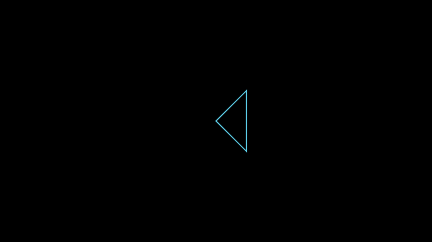

```python
%%manim -v WARNING  --progress_bar None -s -ql --disable_caching Shapes

class Shapes(Scene):
    def construct(self):
        circle = Circle()
        square = Square()
        triangle=Polygon(np.array([0,0,0]),np.array([1,1,0]),np.array([1,-1,0]))

        self.play(Create(circle))
        self.play(FadeOut(circle))
        self.play(GrowFromCenter(square))
        self.play(Transform(square,triangle))
```

The parameters used are:

- `-v WARNING` means that only warnings are shown in the log
- `--progress_bar None` will not show the animation progress bar
- `-s` will only show the last frame
- `-ql` renders in low quality
- `--disable_caching` will disable the manim caching system
- `Shapes` gives the scene name

for rendering a video, just remove the `-s` flag. To lower the resolution, you can use `-r 400,200` (pixel values in x and y direction).

```python
%%manim -v WARNING  --progress_bar None  -r 400,200  --disable_caching HelloManim
class HelloManim(Scene):
    def construct(self):
        self.camera.background_color = "#000000"
        banner_large = ManimBanner(dark_theme=True).scale(0.7)
        self.play(banner_large.create())
        self.play(banner_large.expand())
```

[video not shown]

Note that you can change the background color by using the `self.camera.background_color = "#000000"` command in the `construct` method of the scene.

### Using `parameters`

```python
param = "-v WARNING -s -ql --disable_caching Example"
paramVideo = "-v WARNING --progress_bar None -ql --disable_caching Example"
```

[figure not shown]

```python
%%manim $param
class Example(Scene):
    def construct(self):
        m= ManimBanner()
        self.add(m)
```

Much cleaner, isn't it?

```python
paramVideo = "-v WARNING  --progress_bar None -ql -r 400,200 --disable_caching HelloManim"
```

```python
%%manim $paramVideo
class HelloManim(Scene):
    def construct(self):
        self.camera.background_color = "#000000"
        banner_large = ManimBanner(dark_theme=True).scale(0.7)
        self.play(banner_large.create())
        self.play(banner_large.expand())
```

[video not shown]

## Some More Stuffs

### Initializing Mobjects Outside the Class

```python
paramVideo = "-v WARNING  --progress_bar None -ql -r 400,200 --disable_caching Example"
```

In some cases, it might be convenient to define mobjects outside the Scene class (e.g. for uncluttering or for speeding up the animation).

```python
m = ManimBanner()
```

[figure not shown]

```python
%%manim $paramVideo
class Example(Scene):
    def construct(self):
        m.scale(0.4)
        m.shift(1.5*UP)
        self.add(m)
```

If we call the code again:

[figure not shown]

```python
%%manim $paramVideo
class Example(Scene):
    def construct(self):
        m.scale(0.4)
        m.shift(1.5*UP)
        self.add(m)
```

Wee see that the logo is again shifted and scaled. This is because the `construct` method is called again. To avoid this, we can just pass the refrence to the mobject to the `construct` method:

```python
m_reference = ManimBanner()
```

[figure not shown]

```python
%%manim $paramVideo
class Example(Scene):
    def construct(self):
        m = m_reference.copy()
        m.scale(0.4)
        m.shift(2*UP)
        self.add(m)
```

[figure not shown]

```python
%%manim $paramVideo
class Example(Scene):
    def construct(self):
        m = m_reference.copy()
        m.scale(0.4)
        m.shift(2*UP)
        self.add(m)
```

### Defining Global Mobjects

You can define global mobjects by using the `global` keyword. Then this can be used in some other part of you code:

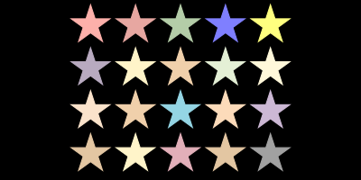

```python
%%manim $paramVideo
class Example(Scene):
    def construct(self):
        stars= VGroup()
        for i in range(0,20):
            s= Star(color= random_bright_color(), fill_opacity=1).scale(0.8)
            stars.add(s)
        stars.arrange_in_grid()
        self.add(stars)
        global favoritstar
        favoritstar = stars[9]
```

[figure not shown]

```python
%%manim $paramVideo
class Example(Scene):
    def construct(self):
        self.add(favoritstar)
```

### Pre-Execute Slow Code

Sometimes, you will want to pre-execute some codes which takes more time to run in `manim` animation. See the example below:

```python
%%time
np.random.seed(20)
steps = np.random.choice(a=[-1, 0, 1], size=(100000,1000))
stop = steps.cumsum(0)
end_points= stop[-1]/stop[-1].max()
end_pointsX = end_points[0:499]
end_pointsY = end_points[500:-1]
```

```
CPU times: user 3.37 s, sys: 623 ms, total: 3.99 s
Wall time: 4 s
```

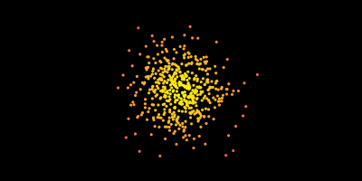

```
CPU times: user 421 ms, sys: 0 ns, total: 421 ms
Wall time: 422 ms
```

```python
%%time
%%manim $paramVideo
class Example(Scene):
    def construct(self):
        radius= (end_pointsX*end_pointsX + end_pointsY * end_pointsY)**0.5
        dots = VGroup()
        for  x,y,r in zip(end_pointsX, end_pointsY,radius):
            c= interpolate_color(YELLOW, RED, r)
            dots.add(Dot(color=c,point=[3*x,3*y,0]).scale(0.7))
        self.add(dots)
```

If we would have run the code inside the `construct` method, it would have taken more time to render the animation (and re-rendering can also be painful). But, by pre-executing the code, we can save some time.

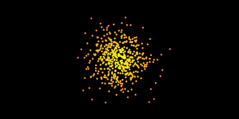

```
CPU times: user 4.32 s, sys: 3.04 s, total: 7.36 s
Wall time: 7.78 s
```

```python
%%time
%%manim $paramVideo
class Example(Scene):
    def construct(self):
        np.random.seed(20)
        steps = np.random.choice(a=[-1, 0, 1], size=(100000,1000))
        stop = steps.cumsum(0)
        end_points= stop[-1]/stop[-1].max()
        end_pointsX = end_points[0:499]
        end_pointsY = end_points[500:-1]

        radius= (end_pointsX*end_pointsX + end_pointsY * end_pointsY)**0.5
        dots = VGroup()
        for  x,y,r in zip(end_pointsX, end_pointsY,radius):
            c= interpolate_color(YELLOW, RED, r)
            dots.add(Dot(color=c,point=[3*x,3*y,0]).scale(0.7))
        self.add(dots)
```

Hurray! We did save a few seconds! However, the use of the precomupatation is when we want to just experiment with the style of our animation but are not changing the overall scene.

## Installing Plugins

Manim hav a number of plugins which can be used to make video creation faster. You can install them by using the `pip` command. Let's install one of them, the `manim-phyics` plugin:

```python
%%manim -v WARNING  --progress_bar None  -qm --disable_caching Example

from manim_physics import *

class Example(SpaceScene):
    def construct(self):
        circle = Dot(radius=1).shift(1.5*LEFT+3*UP)
        rect = Square(color=YELLOW, fill_opacity=1)
        ground = Line([-4, -3.5, 0], [4, -3.5, 0])
        wall1 = Line([-4, -3.5, 0], [-4, 3.5, 0])
        wall2 = Line([4, -3.5, 0], [4, 3.5, 0])
        walls = VGroup(ground, wall1, wall2)
        self.add(walls)
        self.add(rect, circle)
        self.make_rigid_body(rect, circle)
        self.make_static_body(walls)
        self.wait(5)
```

[video not shown]